# Machine Learning Project - Weight Lifting Exercises

Esteban Rodriguez Llamazares

8 de mayo de 2018

## Background

I used the WLE dataset, which takes measurements of body movements via four sensors while the test subject does a given excercise in a correct or incorrect manner. The objective of the project was to create a model that predicts whether an excercis was performed correctly or incorrectly. In the following text, the Classe A is the correct and classes B-E are that same excercise performed incorrectly. I would also like to state that there was no codebook given to the dataset provided and hence could only approach the problem in a statistical manner and have no certainty about the posible cofounding that could be done.

## Data cleaning and separating

From the 159 variables that could be elegible from the original training set I only took 60, which were the only ones which contained any information what-so-ever in the test data set.Why are those the variables that give any information, at this point cannot be assured. Besides that, I disregarded any row in which the variable “New Window” took a value of “YES” since it appeared that the measurements in that row were analyses of the previous window, and besides, the test dataset didn’t contain any of such rows. From this point foreward I will call the given test data as the project’s validation data. The given training data was separated in a train/test sets (p=0.75).

## Training

I used three different methods: Random Forest, Random Forests using PCA and Linear Discriminant Analyses asuming there was some probabilistic strcuture beneath the data, and after that I used Bagging to combine the predictors. For cross validation I used “cv” (CrossValidation) with 3 samples, as the data was large enough (~14,000 obsertions). The choosing of these models was based on the paper found at the website of the WLE Dataset.

#### Random Forest

```r
model2<-train(x=train1[,8:59],y=train1$classe,method="parRF",ntree=50,trControl=my_control)
```

#### Random Forest with PCA’s

```r
prep<-preProcess(train1[,-60],method="pca",thresh=.9)
trainpred<-predict(prep,newdata =train1[,-60])
train3<-data.frame(trainpred[4:24],train1$classe)
model<-train(train1.classe~.,method="parRF",data=train3,ntree=50,trControl=my_control)
```

#### Linear Discriminant Analyses

```r
model3<-train(x=train1[,8:59],y=train1$classe,method="lda",trControl=my_control)
```

## Testing

After producing the models, we tested all three of them into the test data set and calculated the confusion matrix for each one of them, the results being the following:

#### Random Forest

```
##           Reference
## Prediction    A    B    C    D    E
##          A 1366    1    0    0    0
##          B    3  924    2    0    0
##          C    0    4  830    4    0
##          D    0    0    8  777    1
##          E    0    0    0    4  878
##       Accuracy          Kappa  AccuracyLower  AccuracyUpper   AccuracyNull
##      0.9943773      0.9928873      0.9918298      0.9962915      0.2850895
## AccuracyPValue  McnemarPValue
##      0.0000000            NaN
```

#### Random Forest with PCA’s

```
##           Reference
## Prediction    A    B    C    D    E
##          A 1367    0    0    0    0
##          B    8  917    4    0    0
##          C    1    7  821    6    3
##          D    0    0   11  774    1
##          E    0    0    0    3  879
##       Accuracy          Kappa  AccuracyLower  AccuracyUpper   AccuracyNull
##      0.9908372      0.9884067      0.9877186      0.9933346      0.2865473
## AccuracyPValue  McnemarPValue
##      0.0000000            NaN
```

#### Linear Discriminant Analyses

```
##           Reference
## Prediction    A    B    C    D    E
##          A 1113   23  112  114    5
##          B  152  574  119   41   43
##          C   98   76  546   95   23
##          D   38   30  100  586   32
##          E   30  153   83   70  546
##       Accuracy          Kappa  AccuracyLower  AccuracyUpper   AccuracyNull
##   7.007497e-01   6.212441e-01   6.875743e-01   7.136805e-01   2.980008e-01
## AccuracyPValue  McnemarPValue
##   0.000000e+00   7.609509e-53
```

As it can be seen both Random Forest models have a prety good out-of-sample accuracy (too good if you ask me), further more we analyse the posibility of using Bagging to combine the predictors.

```r
combdf<-data.frame(tpred1,tpred3,tpred2,classe=test1$classe)
combmodel<-train(classe~.,data=combdf,method="parRF",ntree=50,trControl=my_control)
```

```
##           Reference
## Prediction    A    B    C    D    E
##          A 1366    1    0    0    0
##          B    1  926    2    0    0
##          C    0    2  827    9    0
##          D    0    0    0  785    1
##          E    0    0    0    0  882
##       Accuracy          Kappa  AccuracyLower  AccuracyUpper   AccuracyNull
##      0.9966681      0.9957854      0.9945948      0.9980943      0.2846731
## AccuracyPValue  McnemarPValue
##      0.0000000            NaN
```

After looking at the results of this last confusion matrix we can see there is no much difference between taking the Random Forest versus the three models “bagged” together, so for the sake of interpretation I decided to take the Random Forest by itself even at the cost of loosing some accuracy. The most importan variables in this models are the roll measured in the belt and the pitch measured in the forearm, we take this two into account to do some plotting.

```
## parRF variable importance
##
##   only 20 most important variables shown (out of 52)
##
##                      Overall
## roll_belt             100.00
## pitch_forearm          60.27
## yaw_belt               56.91
## pitch_belt             45.68
## magnet_dumbbell_y      44.20
## magnet_dumbbell_z      44.01
## roll_forearm           43.82
## accel_dumbbell_y       21.98
## roll_dumbbell          19.24
## accel_belt_z           18.85
## accel_forearm_x        18.18
## magnet_belt_z          17.20
## total_accel_dumbbell   16.30
## magnet_dumbbell_x      15.87
## magnet_belt_y          14.66
## magnet_forearm_z       13.78
## gyros_belt_z           13.65
## accel_dumbbell_z       13.29
## roll_arm               11.78
## magnet_belt_x          11.70
```

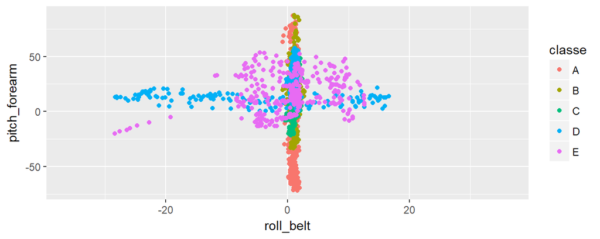

Form the previous figure it can be seen that a variance in the roll of the belt might denote a class D or E type of excercise, this might be a bit clearer in the following Figure:

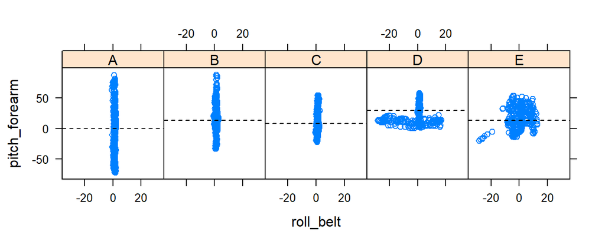

Analysing each of this two regressors we can see that in fact a higher variance in the roll of the belt makes up for a class D or E movement, whilst the average pitch in the forearm should be as close to zero as posible to denote a perfect excercise (classe A), which makes sense because you don’t want the forearm moving up and down whilst doing dumpbells.

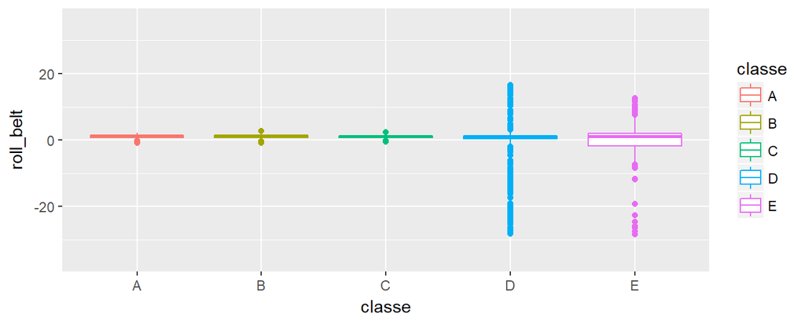

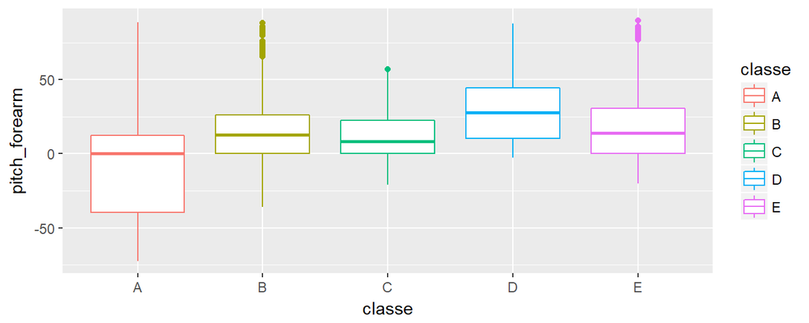

Finally we use the each of the models to predict the classe of the validation dataset, giving the following results, the Random Forest results yields:

```
##  [1] B A B A A E D B A A B C B A E E A B B B
## Levels: A B C D E
```

The RF with the PCA’s gives:

```
##  [1] B A A A A A A B A A A A B A E A A B B B
## Levels: A B C D E
```

The LDA:

```
##  [1] B A B C C E D D A A D A B A E A A B B B
## Levels: A B C D E
```

And the bagged one:

```
##  [1] B A B A A E D B A A B C B A E E A B B B
## Levels: A B C D E
```

As it can be seen, the results of the bagged model and the simple random forest one are exactly the same for the validation data set, which coincidentaly is the correct answer of such validation set.